# Uncertainty exercises

Jon Chernus

```r
library("tidyverse")
```

```r
library("forestplot")
```

## Distribution of sample means

- Use `rnorm` to randomly generate n=5 observations from a normal distribution with mean 100 and standard deviation 10
- Store it as a vector called `x`
- Make a histogram of `x` showing the interval [70,130]
- Add a green vertical line at the population mean
- Add a red vertical line at your sample mean

The distance between the red and green lines represents how close your sample mean is to the “unknown” mean, 100.

Run the chunk numerous times. What do you see?

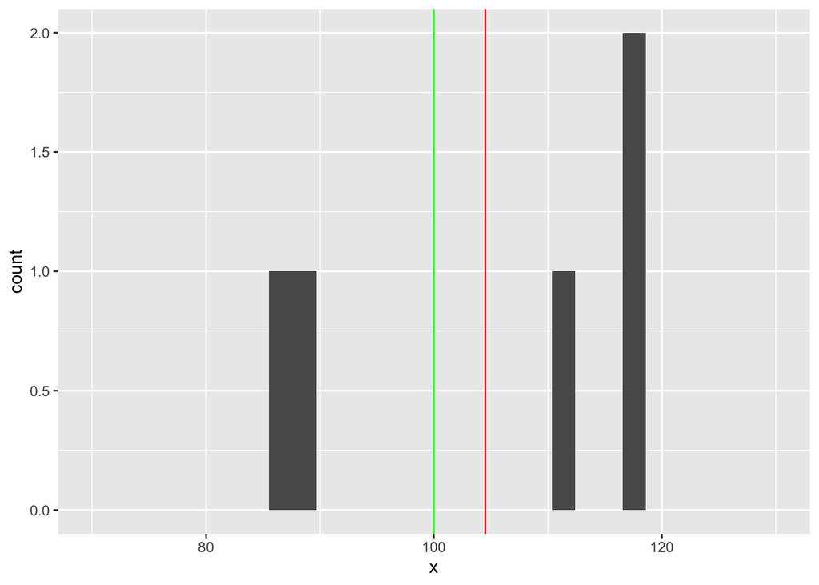

```r
x <- rnorm(n=5, mean=100, sd=10)
x %>%
  as.data.frame(x=.) %>%
  ggplot() +
  geom_histogram(aes(x=x)) +
  xlim(c(70,130)) +
  geom_vline(xintercept = mean(x), color="red") +
  geom_vline(xintercept=100, color="green")
```

You should see that sometimes your red line is close to the green line, but that the distance varies a bit.

In the chunk below, do the same thing, but with n=1000. What do you notice?

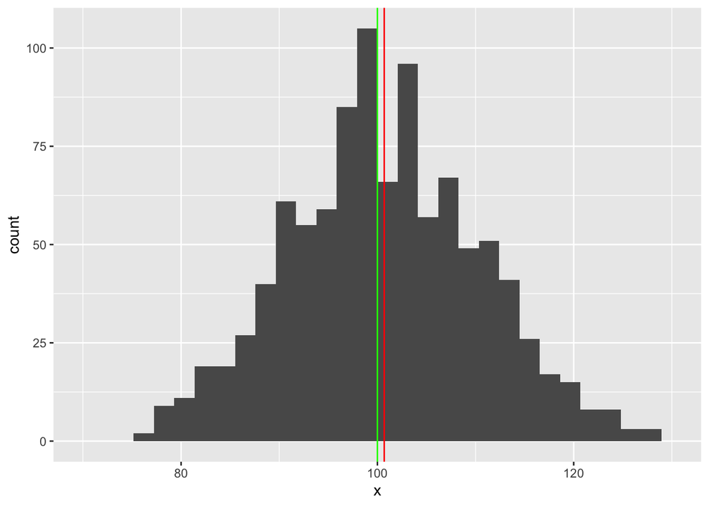

```r
x <- rnorm(n=1000, mean=100, sd=10)
x %>%
  as.data.frame(x=.) %>%
  ggplot() +
  geom_histogram(aes(x=x)) +
  xlim(c(70,130)) +
  geom_vline(xintercept = mean(x), color="red") +
  geom_vline(xintercept=100, color="green")
```

You should see that the distance between the sample mean and the population mean is smaller now, on average.

Instead of clicking the green triangle to re-run the chunk over and over, now we’re going to re-run the experiment with a loop so we can record all the sample means (i.e., the red lines).

A `for` loop looks like this, where `n_simulations` is the number of times we want to iterate the experiment:

```
for (i in 1:n_simulations) {
  # ...
  # Do something
  # ...
  # ...
}
```

Write a `for` loop that

- Takes samples of size n=5 from the same distribution as above
- 10,000 times
- and stores all 10,000 sample means in a vector called `means5`

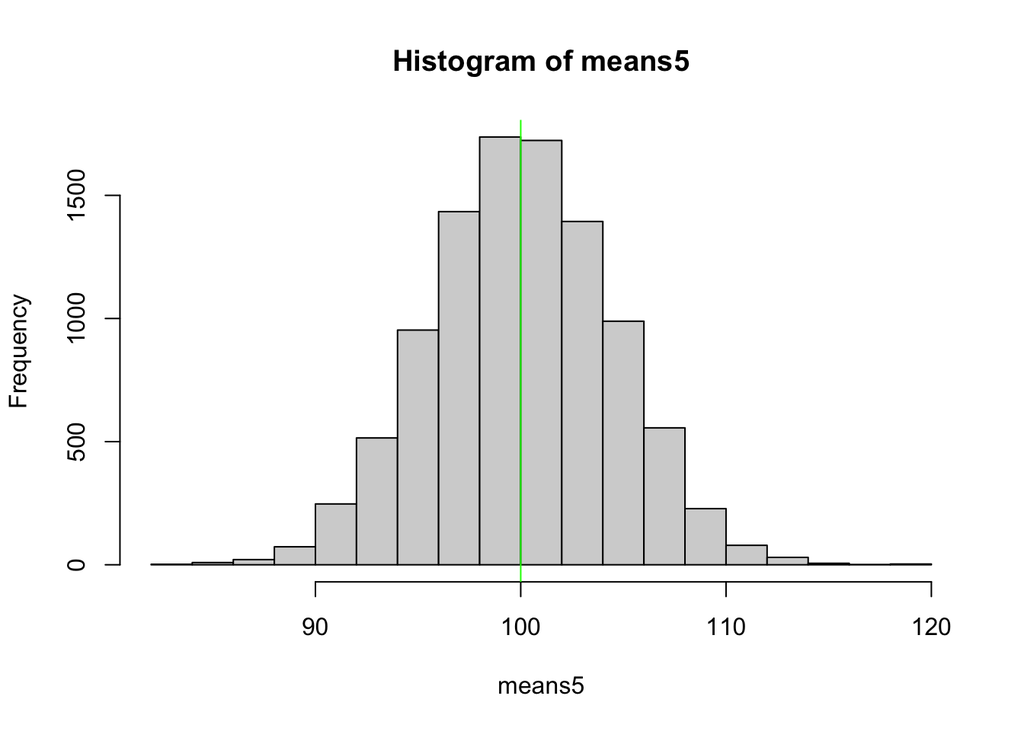

```r
n_simulations <- 10000
means5 <- rep(NA, n_simulations)
for (i in 1:n_simulations) {
  means5[i] <- mean(rnorm(n=5, mean=100, sd=10))
}
hist(means5)
abline(v = 100, col="green")
```

Similarly, generate `means10`, `means100`, `means1000`, and `means10000` and store them as columns in a data frame. (So the data frame should have 10,000 rows and 4 columns.)

```r
d <- data.frame(means10=rep(NA,n_simulations),
                means100=rep(NA,n_simulations),
                means1000=rep(NA,n_simulations),
                means10000=rep(NA,n_simulations)
                )
for (i in 1:n_simulations) {
  d[i,"means10"] <- mean(rnorm(n=10, mean=100, sd=10))
  d[i,"means100"] <- mean(rnorm(n=100, mean=100, sd=10))
  d[i,"means1000"] <- mean(rnorm(n=1000, mean=100, sd=10))
  d[i,"means10000"] <- mean(rnorm(n=10000, mean=100, sd=10))
}
```

Now let’s plot the distributions of `means10`, `means100`, `means1000`, and `means10000` together using overlapping density plots.

First, we need to reshape the data. Use this command:

```
d_long <- d %>%
  pivot_longer(
    cols = starts_with("means"),
    names_to = "window",
    values_to = "mean"
  )
```

Use the code above to reshape the data, and make your plot in the chunk below. (Use `alpha` and a sequential color scale.)

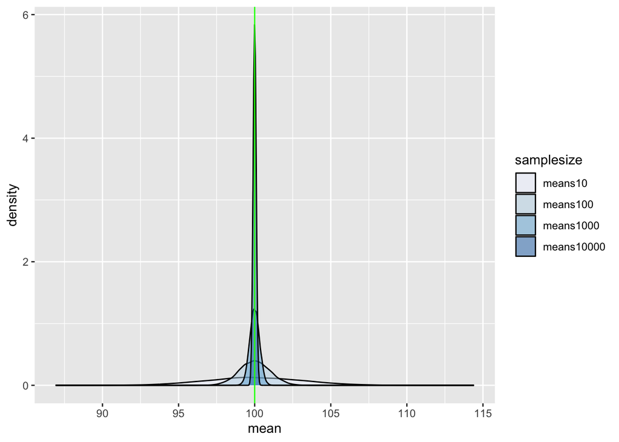

```r
# Paste the command above
# Put your density plot code here
d_long <- d %>%
  pivot_longer(
    cols = starts_with("means"),
    names_to = "samplesize",
    values_to = "mean"
  )

d_long %>%
  ggplot() +
  geom_density(aes(x=mean,fill=samplesize),alpha=0.5) +
  scale_fill_brewer(palette="Blues") +
  geom_vline(xintercept = 100, color="green")
```

What do you notice? Think for a moment about how you could quantify this pattern.

Think of the sample mean itself as a random variable (a function of the random sample of size n). You should see that as the sample size (n) increases, the corresponding sample mean has a tighter and tighter distribution around the “unknown” population mean.

We know the underlying distribution we sampled from had a standard deviation of 10. How is the related to the standard deviations of the variables in our density plot, `mean10`, `mean100`, `mean1000`, and `mean10000`?

It’s a fact in statistics that if you randomly take samples of size n from a distribution with standard deviation $\sigma$, the sample mean will have a distribution of $\sigma / \sqrt{n}$.

Make a scatterplot to show whether your simulations bear out that formula. The scatterplot should show 4 points. Add a linear regression line, too.

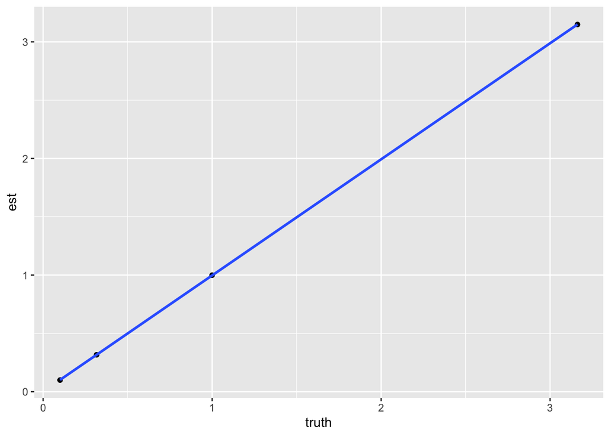

```r
# Your scatterplot code
data.frame(est=c(sd(d$means10),sd(d$means100), sd(d$means1000), sd(d$means10000)),
           truth=10/sqrt(c(10,100,1000,10000))) %>%
  ggplot() +
  geom_point(aes(x=truth,y=est)) +
  geom_smooth(aes(x=truth,y=est),method="lm", se=FALSE)
```

Note that typically $\sigma$ is unknown, so we would estimate it with the sample standard deviation.

Here’s what your plot would look like if we had to estimate $\sigma$ from a single sample in each case:

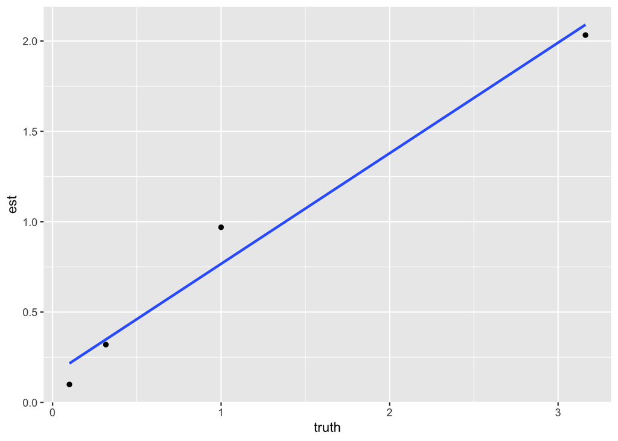

```r
# Your scatterplot code
data.frame(est=c(
  sd(rnorm(n=10, mean=100, sd=10))/sqrt(10),
  sd(rnorm(n=100, mean=100, sd=10))/sqrt(100),
  sd(rnorm(n=1000, mean=100, sd=10))/sqrt(1000),
  sd(rnorm(n=10000, mean=100, sd=10))/sqrt(10000)),
           truth=10/sqrt(c(10,100,1000,10000))) %>%
  ggplot() +
  geom_point(aes(x=truth,y=est)) +
  geom_smooth(aes(x=truth,y=est),method="lm", se=FALSE)
```

Note that all of the above is true even if we sampled from a non-normal distribution.

Let’s try sampling from a weird-looking distribution, beta(0.1, 0.1). It looks like this, not remotely normal:

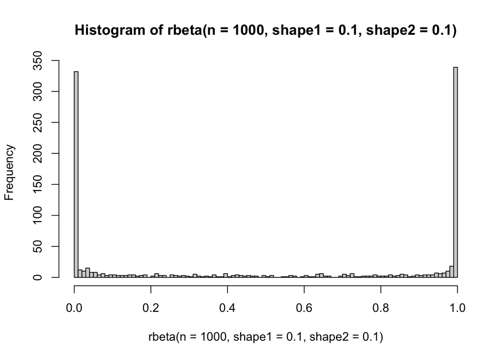

```r
hist(rbeta(n=1000, shape1=0.1, shape2=0.1), breaks=100)
```

As we did with the normal distribution, let’s draw many samples and record their means.

You can see that the sample means become more tightly distributed as sample size increases, even though the underlying distribution was extremely non-normal.

In fact, the central limit theorem says that the sampling distribution of the mean is asymptotically normal; i.e., as the sample size increases, the distribution will converge to a normal distribution.

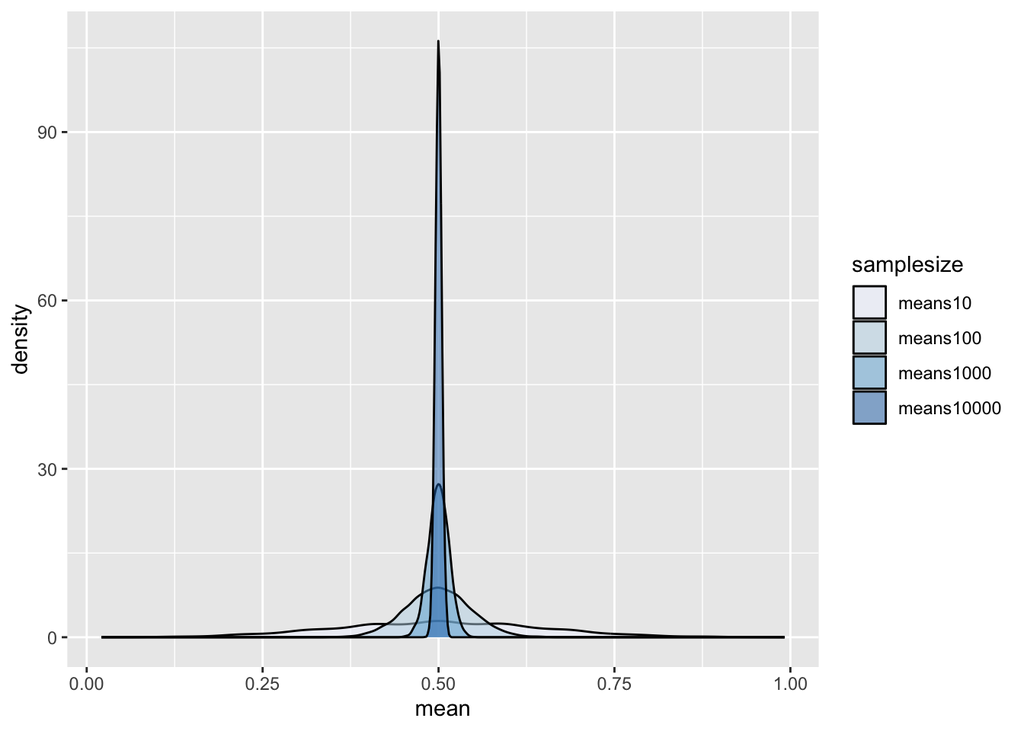

```r
db <- data.frame(means10=rep(NA,n_simulations),
                means100=rep(NA,n_simulations),
                means1000=rep(NA,n_simulations),
                means10000=rep(NA,n_simulations)
                )
for (i in 1:n_simulations) {
  db[i,"means10"] <- mean(rbeta(n=10, shape1=0.1, shape2=0.1))
  db[i,"means100"] <- mean(rbeta(n=100,shape1=0.1, shape2=0.1))
  db[i,"means1000"] <- mean(rbeta(n=1000, shape1=0.1, shape2=0.1))
  db[i,"means10000"] <- mean(rbeta(n=10000, shape1=0.1, shape2=0.1))
}

db_long <- db %>%
  pivot_longer(
    cols = starts_with("means"),
    names_to = "samplesize",
    values_to = "mean"
  )

db_long %>%
  ggplot() +
  geom_density(aes(x=mean,fill=samplesize),alpha=0.5) +
  scale_fill_brewer(palette="Blues")
```

We can also show the variance behaves as expected. Note that the beta distribution with parameters `a` and `b` has variance:

$$\sigma^2 = \frac{ab}{(a+b)^2(a+b+1)}$$

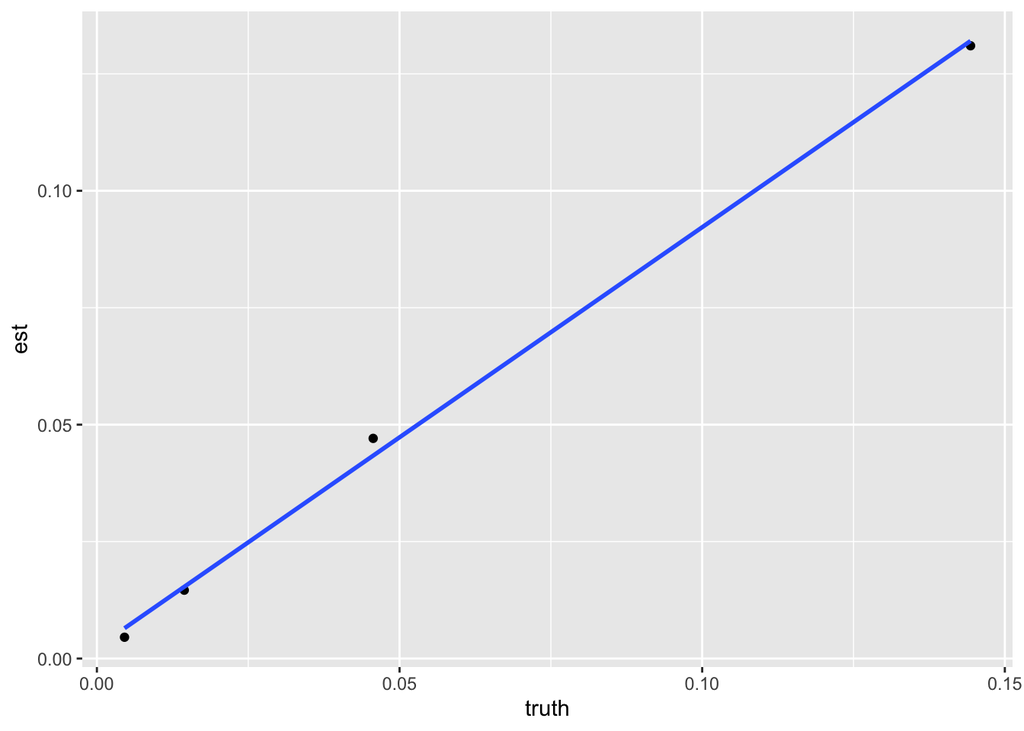

```r
# Your scatterplot code

# Helper function
s_ab <- function(a,b) {sqrt(a*b/((a+b)^2*(a+b+1)))}
s <- s_ab(0.1, 0.1)

data.frame(est=c(
  sd(rbeta(n=10, shape1=0.1, shape2=0.1))/sqrt(10),
  sd(rbeta(n=100, shape1=0.1, shape2=0.1))/sqrt(100),
  sd(rbeta(n=1000, shape1=0.1, shape2=0.1))/sqrt(1000),
  sd(rbeta(n=10000, shape1=0.1, shape2=0.1))/sqrt(10000)),
           truth=s/sqrt(c(10,100,1000,10000))) %>%
  ggplot() +
  geom_point(aes(x=truth,y=est)) +
  geom_smooth(aes(x=truth,y=est),method="lm", se=FALSE)
```

## Error bars

Now let’s simulate gene expression in two groups, treatment and control, each with sample size n=10.

First, let’s make barplots of the group means, with the raw data on top.

One way to do this would be by doing `group_by() %>% summarize()` and `geom_col`.

Another way would let us use the raw data: `stat_summary(fun=mean, geom="col")`. Note that this syntax can be extended for drawing the error bars.

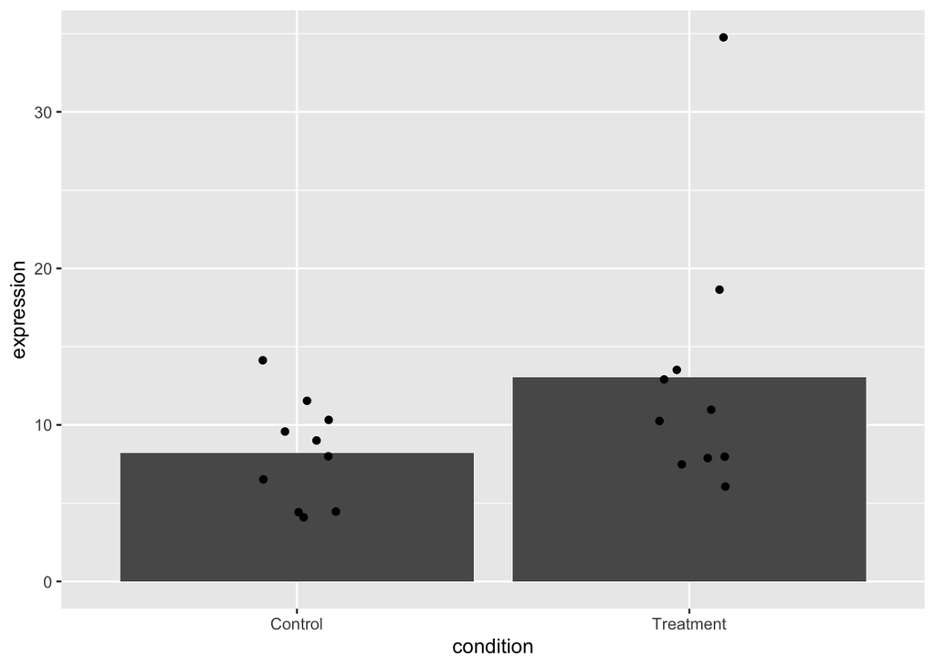

```r
set.seed(2073)
df <- tibble(
  condition = rep(c("Control", "Treatment"), each = 10),
  expression = c(
    rlnorm(10, meanlog = 2.0, sdlog = 0.4),
    rlnorm(10, meanlog = 2.3, sdlog = 0.4)
  )
)

barplot <- df %>%
  ggplot(., aes(x = condition, y = expression)) +
  stat_summary(
    fun = mean,
    geom = "col"
  ) +
  geom_jitter(position=position_jitter(width=0.1))
barplot
```

We can add error bars with `geom_errorbar` or `stat_summary`. Let’s try `stat_summary`.

```
## No summary function supplied, defaulting to `mean_se()`
```

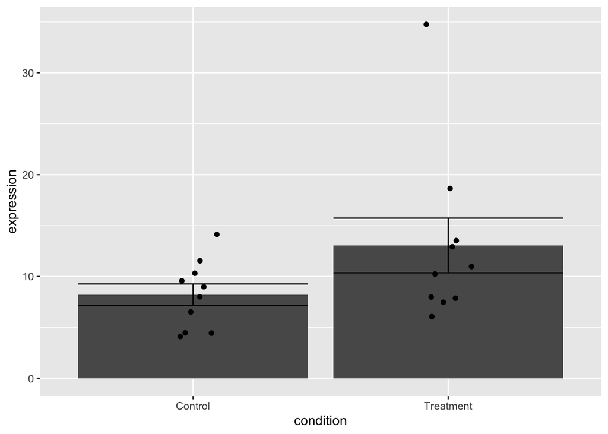

```r
barplot +
  stat_summary(
    geom="errorbar"
  )
```

Notice the default half-width is `mean_se()`

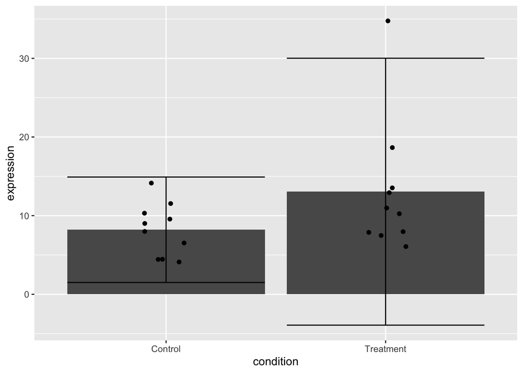

```r
barplot +
  stat_summary(
    geom="errorbar",
    fun.data=mean_sdl
  )
```

Or a standard 95% confidence interval:

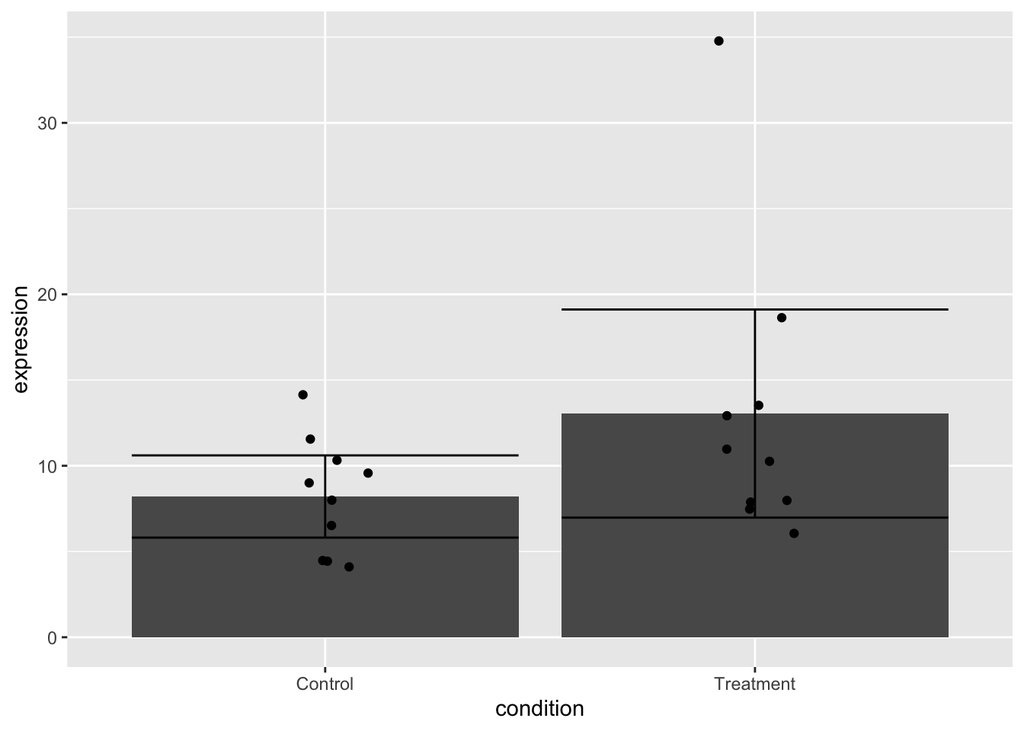

```r
barplot +
  stat_summary(
    geom="errorbar",
    fun.data=mean_cl_normal
  )
```

Or any other kind of confidence interval, e.g., 90%:

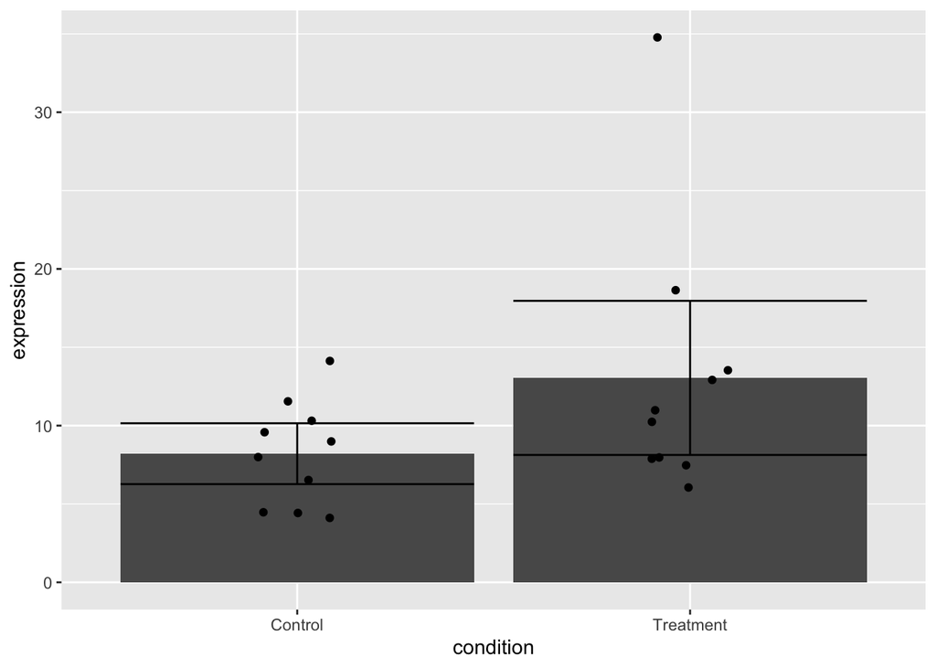

```r
barplot +
  stat_summary(
    geom="errorbar",
    fun.data=function(x) mean_cl_normal(x, conf.int = 0.90)
  )
```

## Confidence intervals and forest plots

Suppose we have several confidence intervals estimating the same quantity, e.g., the effect of some SNP on risk of a disease.

A forest plot shows all of indivdual confidence intervals, plus a meta-analytic confidence interval.

There are numerous ways to make forest plots in R.

- The `meta` and `metafor` packages (specifically for meta-analysis)
- The `forestplot` package (assumes you already have done all the calculations)
- `geom_errorbarh()` in `ggplot2`

The example below uses `forestplot`, which allows you to add an annotation table next to the plot.

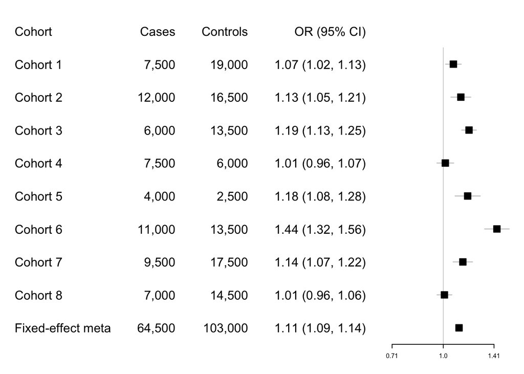

```r
set.seed(2073)
# Simulate GWAS-like odds ratios across 8 cohorts
k <- 8

dat <- tibble(
  cohort = paste0("Cohort ", seq_len(k)),
  n_cases    = sample(seq(2000, 12000, by = 500), k, replace = TRUE),
  n_controls = sample(seq(2000, 20000, by = 500), k, replace = TRUE),
  # simulate log(OR) around a modest effect
  logOR = rnorm(k, mean = log(1.12), sd = 0.08),
  # simulate SE loosely tied to total N (just for realism)
  se = sqrt(4 / (n_cases + n_controls)) + runif(k, 0.01, 0.03)
) %>%
  mutate(
    OR = exp(logOR),
    lo = exp(logOR - 1.96 * se),
    hi = exp(logOR + 1.96 * se)
  )

# Inverse-variance fixed-effect meta-analysis
w <- 1 / dat$se^2
logOR_meta <- sum(w * dat$logOR) / sum(w)
se_meta <- sqrt(1 / sum(w))

meta_row <- tibble(
  cohort = "Fixed-effect meta",
  n_cases = sum(dat$n_cases),
  n_controls = sum(dat$n_controls),
  logOR = logOR_meta,
  se = se_meta,
  OR = exp(logOR_meta),
  lo = exp(logOR_meta - 1.96 * se_meta),
  hi = exp(logOR_meta + 1.96 * se_meta)
)

dat2 <- bind_rows(dat, meta_row)

# Build the left-side table text
tabletext <- cbind(
  c("Cohort", dat2$cohort),
  c("Cases", format(dat2$n_cases, big.mark = ",")),
  c("Controls", format(dat2$n_controls, big.mark = ",")),
  c("OR (95% CI)",
    sprintf("%.2f (%.2f, %.2f)", dat2$OR, dat2$lo, dat2$hi))
)

# Forest plot
forestplot(
  labeltext = tabletext,
  mean  = c(NA, dat2$OR),
  lower = c(NA, dat2$lo),
  upper = c(NA, dat2$hi),
  zero  = 1, # null for OR is 1
  xlog  = TRUE, # plot on log scale
  boxsize = 0.2,
  lineheight = "auto",
  col = fpColors()
)
```